# Ford go bike System Data

# Data wrangling

**This is a quick data wrangling to perfectly tackle my questions in Exploratory sections**

**First, i changed the data type for start_time,end_time to datetime**

**Second, I added new column for age. The values in there were calucated on the basis of data collection year which is 2019**

**Third, i Added new column for period of day**

**Fourth, i added new column for number of week for the month menioned**

# Univariant Exploration :

**Q1: Which group of people come more than another one? is it company's subscriber or regular customer?**

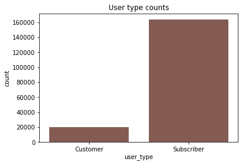

```python
base_color = sb.color_palette()[5]
sb.countplot(data = df , x = 'user_type', color = base_color)
plt.title('User type counts');
```

**As shown above, most of the riders was subscribers of the company.**

**Q2:At usual basis, who is ride bikes more frequently?**

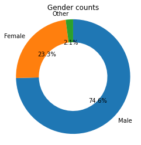

```python
sorted_counts = df['member_gender'].value_counts()

plt.pie(sorted_counts, labels = sorted_counts.index, startangle = 90,
        counterclock = False, wedgeprops = {'width' : 0.4}, autopct='%1.1f%%');
plt.axis('square')
plt.title('Gender counts');
```

**74% of riders were male. However, only 23 were female and 2% from other.**

**Q3:How much is the average total seconds for riding a bike?**

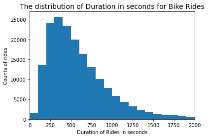

```python
bins = np.arange(0, df['duration_sec'].max() +100 ,100)
plt.hist(data = df , x = 'duration_sec', bins = bins)
plt.xlabel('Duration of Rides in seconds');
plt.ylabel('Counts of rides');
plt.title('The distribution of Duration in seconds for Bike Rides', fontsize = 14);
plt.xlim(0, 2000);
```

**The data is right skewed. with the maximum of number of rides (25000) with 300 sec then it is gradually decreased**

# Bivariant Exploration :

**Q1:Is there any relationship between gender and subscribtion?** clustered bar chart

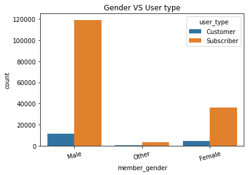

```python
sb.countplot(data = df , x = 'member_gender' , hue = 'user_type')
plt.xticks(rotation = 15)
plt.title('Gender VS User type');
```

**Male subscriber more than female subscriber**

**Q2:Is there any relationship between the age of the person and duration of riding a bike?**line plot

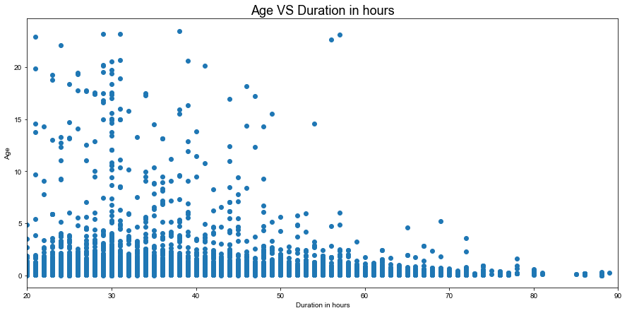

```python
plt.figure(figsize = (15, 7))
plt.scatter(data = df, x = 'Age', y = 'duration_hours' , alpha= 1);
xaxis = plt.gca()
xaxis.set_xlim([20,90])
plt.style.use('seaborn')
plt.xlabel('Duration in hours')
plt.ylabel('Age')
plt.title('Age VS Duration in hours',fontsize = 18)
```

**Interpretation: People around age 30 tend to take the longest rides. Also; the older they became, the less ride duration they did.**

**Q3:Is there any relationship between the period of the day and duration of riding a bike?**

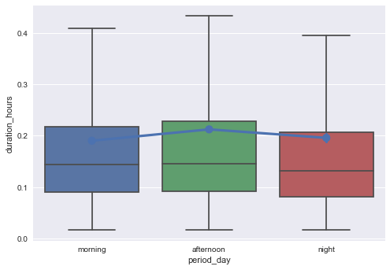

```python
sb.boxplot(data = df ,x = 'period_day' ,y = 'duration_hours',showfliers=False)
sb.pointplot(data = df ,x = 'period_day' ,y = 'duration_hours')
```

**The longest rides took place at afternoon period with a wider range of duration as well.**

**Q4:How many people came at (morning , afternoon , night) from each gender?**

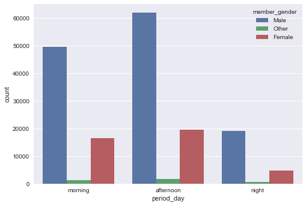

```python
sb.countplot(data = df , x = 'period_day', hue = 'member_gender' )
```

**Male riders is the dominant majority for all of day periods especially at afternoon in contrast with other periods.**

# Multivariate Exploration :

**Q:For each week of february , what period most often people went riding and what is the hourly duration for them?**

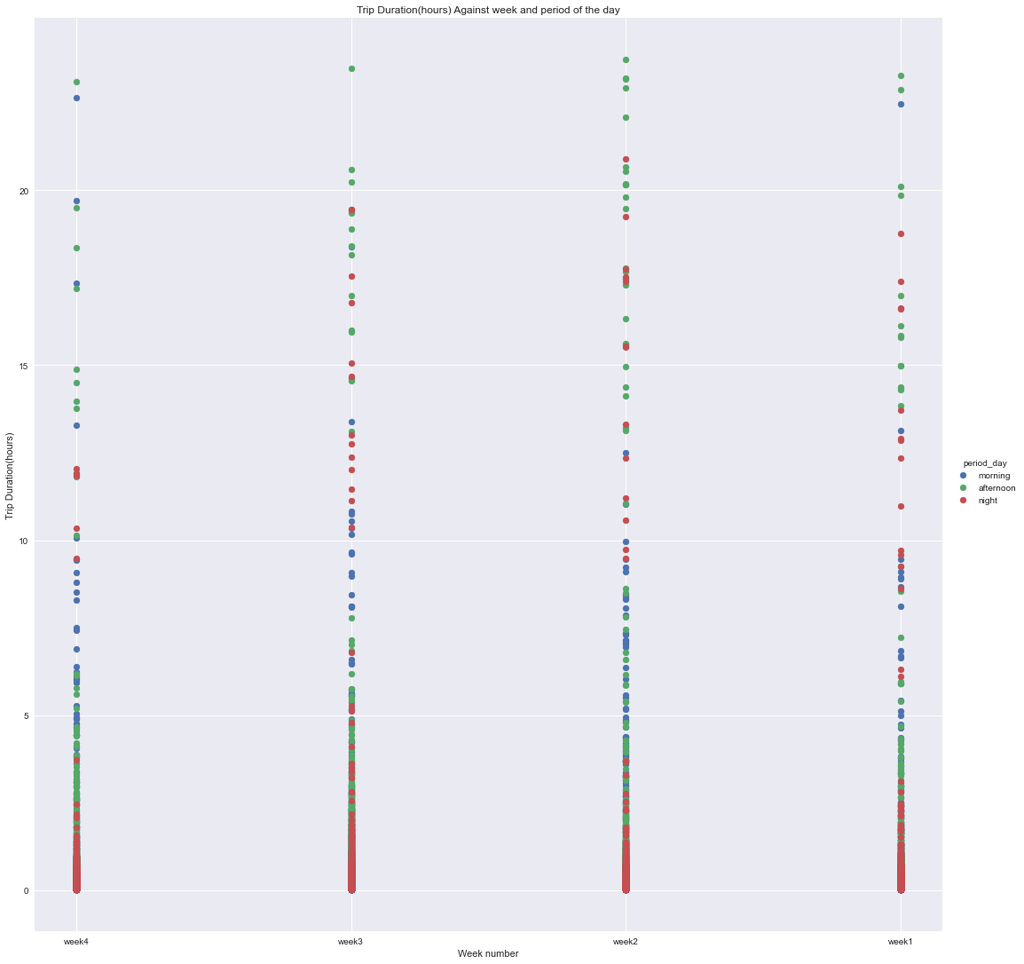

```python
sb.FacetGrid(df,hue = "period_day",height = 15).map(plt.scatter,"week_num","duration_hours").add_legend();
plt.title('Trip Duration(hours) Against week and period of the day')
plt.xlabel('Week number')
plt.ylabel('Trip Duration(hours)')
plt.show();
```